# Google Search and the Exercise of Strategic Default on Mortgages

Marcato, Watanabe and Zhu (2025) — **Discussion**

Luís Teles Morais

Nova School of Business and Economics

AREUEA International Conference 2025  
IESE, Barcelona, **16 July 2025**

## Summary

#### **RQ: Can a Google-search “Strategic Default Risk Index” (SDRI) predict opportunistic mortgage default?**

#### Main empirical results

- **+0.39 log-odds** (≈ +47 % odds) and **+0.20 pp** default probability per +1 σ SDRI – applies to underwater (>100 % CLTV) high‑FICO loans
- Effect **only present in non-recourse states**
- SDRI tracks well strategic default rates

#### Identification strategy

- **Treatment (shock):** monthly, state-level SDRI built from 5 “walk-away” keywords
- **Outcome:** loan-level default indicator, 3.2 M Fannie Mae 30-yr FRM loan-months, 2008-13
- **Econometric design**: panel logit with loan, month & ZIP FEs
  - Triple interaction *SDRI × Negative-Equity × High-FICO* (defines “strategic”)
  - **IV:** population-weighted SDRI in *other* states to address simultaneity

**My comments:** clarify *channels* (+ think more about IV, external validity)

## Summary

#### **RQ: Can a Google-search “Strategic Default Risk Index” (SDRI) predict opportunistic mortgage default?**

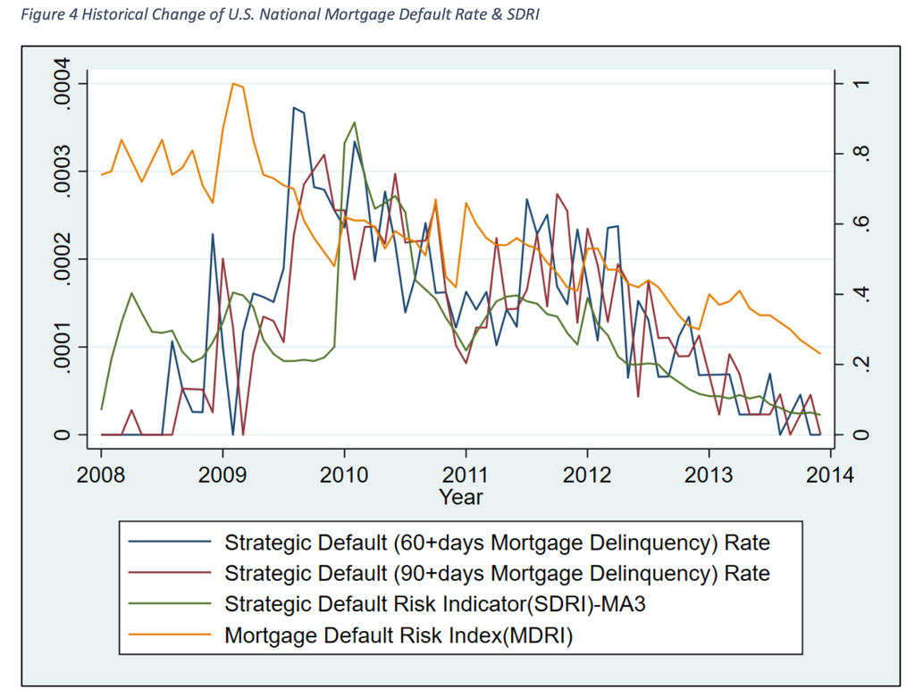

## #1. Main comment — theoretical benchmark

#### When does a homeowner walk?

$$\underbrace{-m_t}_{\text{payment}}
\;+\;\beta\,\mathbb{E}_t[V^{\text{keep}}_{t+1}]
\;<\;
\underbrace{-\color{red}{\lambda_t}}_{\text{legal / credit}}
\;-\;\underbrace{\color{orange}{\kappa_t}}_{\text{moving}}
\;-\;\underbrace{\color{purple}{\psi_t}}_{\text{stigma}}
\;+\;\beta\,\mathbb{E}_t[V^{\text{rent}}_{t+1}]$$

| symbol | economic content | data? |
| --- | --- | --- |
| $m_t$ | payment flow | observed |
| $\color{red}{\lambda_t}$ | legal & credit penalties | partly observed |
| $\color{orange}{\kappa_t}$ | relocation / quality gap | proxied |
| $\color{purple}{\psi_t}$ | stigma / reputation | unobserved |

#### Q: What is the incremental value of SDRI beyond observables? Paper will benefit from clearer story

1. **Missing fundamentals** — proxies for shocks to $m_t$ or $\mathbb{E}_t[HP]$.
2. **Legal-cost learning** — searches reveal $\color{red}{\lambda_t}\!\approx 0$ in non-recourse states.
3. **Stigma shift** — buzz lowers $\color{purple}{\psi_t}$.
4. **Neighbour contagion** — coordination dynamics outside the equation.

## Competing stories (I)

- **Missing fundamentals** ($m_t$, $\mathbb{E}_t[HP]$)
  - ZIP-level HPI & borrower income unobserved → plausible
  - Paper: state HPI & unemployment controls don’t kill SDRI
  - Try: add UI claims or “housing-crash” sentiment index
- **Legal-cost learning** ($\lambda_t$)
  - Some evidence that many HHs mis-perceive legislation → plausible
    - Aggregate shocks could = attention shocks, leading people to search
  - Paper: effect only in non-recourse states
  - Try: use variation in education, financial literacy, or legal knowledge (from surveys)
    - More data-intensive: exploit news shocks?

## Competing stories (II)

- **Stigma shift** ($\psi_t$)
  - Social norms can move: media trends, generational, immigration…
  - Paper: is this main story?
  - Try: could try interact SDRI with county religiosity or other proxy for social norms
- **Neighbour contagion**
  - Defaults cluster spatially; herd effect plausible
  - Paper: not tested
  - Try: add lagged neighbourhood defaults; if SDRI fades, contagion dominates
    - Harder: social networks data? (Bailey et al, etc.)

## Further comments

#### #1. Identification strategy — IV

- **Instrument** = population-weighted SDRI in *other* states
- Potential issue: nationwide news shocks
  - National news shocks (e.g., CFPB rule, viral CNBC segment) that hit all states simultaneously would lead to failure of exclusion restriction
- **Suggestion:** Lag-structure IV – use *yesterday* search intensity in time-zone-shifted states à-la Choi-Varian

#### External validity — beyond conforming GSE loans

Sample: Fannie 30-yr FRMs → **excludes jumbo / subprime**.

- But some evidence from 2008 shows strategic default **also common in larger non-conforming loans**:
  - Survey evidence: strategic share **≈ 35 %** of defaults overall (Guiso-Sapienza-Zingales 2013).
  - PSID micro (Gerardi et al. 2018): **38 %** of defaults have ability-to-pay characteristics
- **Suggestion:** try find some data (CoreLogic ?) to capture jumbo & investor properties

## Smaller points

- IV table: report *exact* re-sampling draws for Google Trends (replicability).
- Introduction needs preview of results
- Map figure: show only included states (drop D.C., territories).
- Minor typo p. 23 footnote 7 (dates reversed).

# Thank you

Reach out: **luistelesm.github.io** | **luis.teles.m@novasbe.pt**